# Lecturer Questions: Data summary

George Kinnear

17/11/2021

```r
library(tidyverse)
library(janitor)

# Tables
library(knitr)
library(kableExtra)
basic_kable = function(df, ...) {
  df %>%
    kable(...) %>%
    kable_styling(bootstrap_options = "striped", full_width = F)
}

# Plot styling
theme_set(theme_minimal())
```

```r
all_qs_all_lecs <- read_csv("data/ANON_LQ_Maths_All.csv")
anon_courses <- read_csv("data/ANON_courses.csv")

codes <- c("A", "C", "E", "F", "N", "O", "P", "U", "W", "X")
# Collapsing C, P, X, O into Other
collapsed_codes <- c("A", "O", "E", "F", "N", "O", "O", "U", "W", "O")

code_names <- c("Admin", "Convention", "Evaluation", "Fact", "Next step", "Other",
                "Proof framework", "Understanding check", "Warrant", "Example generation")

code_details <- tibble(code = codes, code_name = code_names) %>%
  mutate(
    collapsed_code = case_when(
      code %in% c("C", "P", "X", "O") ~ "Other",
      TRUE ~ code_name
    )
  ) %>%
  add_row(
    code = "Total",
    code_name = "Total",
    collapsed_code = "Total"
  )
```

```r
# Making list of all lectures and category code combos
lec_cat <- expand_grid(
  all_qs_all_lecs %>% select(course, session) %>% distinct(),
  category = codes
)
```

# Summary of the data

Codes used to categorise questions:

```r
code_details %>%
  basic_kable()
```

| code | code_name | collapsed_code |
| --- | --- | --- |
| A | Admin | Admin |
| C | Convention | Other |
| E | Evaluation | Evaluation |
| F | Fact | Fact |
| N | Next step | Next step |
| O | Other | Other |
| P | Proof framework | Other |
| U | Understanding check | Understanding check |
| W | Warrant | Warrant |
| X | Example generation | Other |
| Total | Total | Total |

## Summary of courses

```r
course_demographics <- anon_courses %>%
  left_join(all_qs_all_lecs %>% select(course, session) %>% distinct(), by = c("anon_code" = "course")) %>%
  group_by(anon_course, anon_nickname) %>%
  summarise(
    course_level = first(course_level),
    course_topic = first(course_topic),
    room_capacity = max(room_cap),
    num_lecturers = n_distinct(anon_lec),
    num_lectures = n(),
    .groups = "drop"
  ) %>%
  separate(course_level, into = c("M_or_E", "year"), sep = 1)  %>%
  select(
    year,
    course_code = anon_course,
    course_codename = anon_nickname,
    course_topic,
    room_capacity,
    num_lecturers,
    num_lectures
  ) %>%
  mutate(
    room_capacity_approx = round(room_capacity/25, digits = 0)*25
  ) %>%
  relocate(room_capacity_approx, .after = room_capacity) %>%
  arrange(year, -room_capacity, -num_lectures, -num_lecturers, course_topic)

course_demographics %>%
  select(-room_capacity) %>%
  rename(
    "Year" = year,
    "Course code" = course_code,
    "Course codename" = course_codename,
    "Topic" = course_topic,
    "Room capacity (approx.)" = room_capacity_approx,
    "Number of lecturers" = num_lecturers,
    "Number of lectures" = num_lectures
  ) %>%
  adorn_totals(c("row")) %>%
  kable(booktabs = T) %>%
  kable_styling(full_width = F) %>%
  collapse_rows(columns = 1, latex_hline = "major", valign = "top")
```

Year

Course code

Course codename

Topic

Room capacity (approx.)

Number of lecturers

Number of lectures

1

1A

1Calc

Calculus

475

6

24

1B

1EngA

Engineering mathematics

475

2

8

1C

1LinAlg

Linear algebra

350

4

40

1D

1Pure

Pure mathematics

200

2

8

1E

1EngB

Engineering mathematics

200

2

8

1F

1DatSci

Data science

200

1

4

2

2A

2Prob

Probability

375

1

4

2B

2Pure

Pure mathematics

325

3

12

2C

2Calc

Calculus

325

1

4

2D

2Stat

Statistics

325

1

4

3

3A

3Alg

Algebra

200

1

4

3B

3CAn

Complex analysis

200

1

4

3C

3DEs

Differential equations

200

1

4

3D

3NDEs

Differential equations

150

1

4

4

4A

4GrpTh

Group theory

100

1

4

Total

4100

28

136

## Courses, lecturers, and question counts

```r
all_qs_all_lecs %>%
  group_by(course) %>%
  summarise(
    #num_qs = n(),
    num_qs = sum(!is.na(category)), # to count only rows with a question identified
    num_lectures = n_distinct(session),
    .groups = "drop"
  ) %>%
  separate(course, c("course", "lecturer")) %>%
  adorn_totals() %>%
  basic_kable(booktabs = T)
```

course

lecturer

num_qs

num_lectures

1A

L1

42

4

1A

L2

64

4

1A

L3

3

4

1A

L4

0

4

1A

L5

21

4

1A

L6

21

4

1B

L7

13

4

1B

L8

7

4

1C

L15

216

11

1C

L16

706

15

1C

L17

302

10

1C

L5

18

4

1D

L17

131

4

1D

L21

60

4

1E

L18

9

4

1E

L19

171

4

1F

L14

183

4

2A

L22

74

4

2B

L10

106

4

2B

L8

19

4

2B

L9

20

4

2C

L23

35

4

2D

L24

21

4

3A

L11

40

4

3B

L12

12

4

3C

L13

39

4

3D

L20

23

4

4A

L10

104

4

Total

2460

136

## Questions by category

```r
all_qs_all_lecs %>%
  tabyl(course, category) %>%
  select(-"NA_") %>%
  as_tibble() %>% # fix as discussed at https://github.com/sfirke/janitor/issues/527
  adorn_totals(c("row", "col")) %>%
  basic_kable(booktabs = T)
```

| course | A | C | E | F | N | O | P | U | W | X | Total |
| --- | --- | --- | --- | --- | --- | --- | --- | --- | --- | --- | --- |
| 1A_L1 | 0 | 0 | 3 | 7 | 10 | 0 | 0 | 7 | 14 | 1 | 42 |
| 1A_L2 | 18 | 0 | 1 | 11 | 21 | 0 | 0 | 7 | 6 | 0 | 64 |
| 1A_L3 | 3 | 0 | 0 | 0 | 0 | 0 | 0 | 0 | 0 | 0 | 3 |
| 1A_L4 | 0 | 0 | 0 | 0 | 0 | 0 | 0 | 0 | 0 | 0 | 0 |
| 1A_L5 | 1 | 0 | 0 | 1 | 0 | 0 | 0 | 15 | 3 | 1 | 21 |
| 1A_L6 | 2 | 0 | 3 | 2 | 6 | 0 | 0 | 8 | 0 | 0 | 21 |
| 1B_L7 | 1 | 0 | 1 | 3 | 0 | 1 | 0 | 7 | 0 | 0 | 13 |
| 1B_L8 | 3 | 0 | 0 | 1 | 2 | 0 | 0 | 0 | 1 | 0 | 7 |
| 1C_L15 | 18 | 3 | 15 | 37 | 29 | 5 | 0 | 83 | 21 | 5 | 216 |
| 1C_L16 | 18 | 0 | 64 | 121 | 192 | 8 | 1 | 160 | 137 | 5 | 706 |
| 1C_L17 | 42 | 0 | 44 | 24 | 63 | 4 | 3 | 90 | 27 | 5 | 302 |
| 1C_L5 | 1 | 0 | 0 | 5 | 0 | 0 | 0 | 6 | 6 | 0 | 18 |
| 1D_L17 | 7 | 0 | 18 | 10 | 28 | 6 | 0 | 53 | 9 | 0 | 131 |
| 1D_L21 | 1 | 0 | 1 | 23 | 14 | 0 | 0 | 14 | 2 | 5 | 60 |
| 1E_L18 | 2 | 0 | 0 | 4 | 1 | 0 | 0 | 0 | 2 | 0 | 9 |
| 1E_L19 | 19 | 0 | 11 | 90 | 15 | 0 | 0 | 35 | 1 | 0 | 171 |
| 1F_L14 | 18 | 1 | 11 | 64 | 16 | 9 | 0 | 31 | 30 | 3 | 183 |
| 2A_L22 | 4 | 0 | 11 | 20 | 3 | 0 | 0 | 21 | 7 | 8 | 74 |
| 2B_L10 | 2 | 0 | 0 | 19 | 45 | 0 | 3 | 14 | 21 | 2 | 106 |
| 2B_L8 | 3 | 0 | 1 | 5 | 3 | 0 | 1 | 4 | 0 | 2 | 19 |
| 2B_L9 | 3 | 0 | 7 | 0 | 0 | 0 | 0 | 9 | 1 | 0 | 20 |
| 2C_L23 | 7 | 0 | 0 | 2 | 1 | 0 | 0 | 24 | 1 | 0 | 35 |
| 2D_L24 | 0 | 0 | 0 | 0 | 2 | 1 | 0 | 18 | 0 | 0 | 21 |
| 3A_L11 | 0 | 0 | 10 | 6 | 0 | 3 | 0 | 3 | 2 | 16 | 40 |
| 3B_L12 | 1 | 0 | 0 | 0 | 0 | 0 | 0 | 10 | 1 | 0 | 12 |
| 3C_L13 | 6 | 0 | 7 | 17 | 7 | 0 | 0 | 1 | 1 | 0 | 39 |
| 3D_L20 | 4 | 0 | 0 | 3 | 2 | 0 | 0 | 14 | 0 | 0 | 23 |
| 4A_L10 | 3 | 0 | 2 | 41 | 27 | 1 | 0 | 19 | 11 | 0 | 104 |
| Total | 187 | 4 | 210 | 516 | 487 | 38 | 8 | 653 | 304 | 53 | 2460 |

Number of questions that are mathematical, i.e. not Admin or Understanding checks:

```r
## Total number of questions
all_qs_all_lecs %>%
  #filter(category != "A" & category != "U") %>%
  tabyl(course, category) %>%
  select(-"NA_", -A, -U) %>%
  as_tibble() %>% # fix as discussed at https://github.com/sfirke/janitor/issues/527
  adorn_totals(c("row", "col")) %>%
  basic_kable(booktabs = T)
```

| course | C | E | F | N | O | P | W | X | Total |
| --- | --- | --- | --- | --- | --- | --- | --- | --- | --- |
| 1A_L1 | 0 | 3 | 7 | 10 | 0 | 0 | 14 | 1 | 35 |
| 1A_L2 | 0 | 1 | 11 | 21 | 0 | 0 | 6 | 0 | 39 |
| 1A_L3 | 0 | 0 | 0 | 0 | 0 | 0 | 0 | 0 | 0 |
| 1A_L4 | 0 | 0 | 0 | 0 | 0 | 0 | 0 | 0 | 0 |
| 1A_L5 | 0 | 0 | 1 | 0 | 0 | 0 | 3 | 1 | 5 |
| 1A_L6 | 0 | 3 | 2 | 6 | 0 | 0 | 0 | 0 | 11 |
| 1B_L7 | 0 | 1 | 3 | 0 | 1 | 0 | 0 | 0 | 5 |
| 1B_L8 | 0 | 0 | 1 | 2 | 0 | 0 | 1 | 0 | 4 |
| 1C_L15 | 3 | 15 | 37 | 29 | 5 | 0 | 21 | 5 | 115 |
| 1C_L16 | 0 | 64 | 121 | 192 | 8 | 1 | 137 | 5 | 528 |
| 1C_L17 | 0 | 44 | 24 | 63 | 4 | 3 | 27 | 5 | 170 |
| 1C_L5 | 0 | 0 | 5 | 0 | 0 | 0 | 6 | 0 | 11 |
| 1D_L17 | 0 | 18 | 10 | 28 | 6 | 0 | 9 | 0 | 71 |
| 1D_L21 | 0 | 1 | 23 | 14 | 0 | 0 | 2 | 5 | 45 |
| 1E_L18 | 0 | 0 | 4 | 1 | 0 | 0 | 2 | 0 | 7 |
| 1E_L19 | 0 | 11 | 90 | 15 | 0 | 0 | 1 | 0 | 117 |
| 1F_L14 | 1 | 11 | 64 | 16 | 9 | 0 | 30 | 3 | 134 |
| 2A_L22 | 0 | 11 | 20 | 3 | 0 | 0 | 7 | 8 | 49 |
| 2B_L10 | 0 | 0 | 19 | 45 | 0 | 3 | 21 | 2 | 90 |
| 2B_L8 | 0 | 1 | 5 | 3 | 0 | 1 | 0 | 2 | 12 |
| 2B_L9 | 0 | 7 | 0 | 0 | 0 | 0 | 1 | 0 | 8 |
| 2C_L23 | 0 | 0 | 2 | 1 | 0 | 0 | 1 | 0 | 4 |
| 2D_L24 | 0 | 0 | 0 | 2 | 1 | 0 | 0 | 0 | 3 |
| 3A_L11 | 0 | 10 | 6 | 0 | 3 | 0 | 2 | 16 | 37 |
| 3B_L12 | 0 | 0 | 0 | 0 | 0 | 0 | 1 | 0 | 1 |
| 3C_L13 | 0 | 7 | 17 | 7 | 0 | 0 | 1 | 0 | 32 |
| 3D_L20 | 0 | 0 | 3 | 2 | 0 | 0 | 0 | 0 | 5 |
| 4A_L10 | 0 | 2 | 41 | 27 | 1 | 0 | 11 | 0 | 82 |
| Total | 4 | 210 | 516 | 487 | 38 | 8 | 304 | 53 | 1620 |

# Questions by category and lecture

```r
count_qs_by_cat = all_qs_all_lecs %>%
  mutate(
    lecture = paste(course, session)
  ) %>%
  tabyl(lecture, category) %>%
  select(-"NA_") %>%
  separate(
    col = lecture,
    into = c("course", "session"),
    sep = " "
  ) %>%
  adorn_totals(c("col"))

count_qs_by_cat %>%
  arrange(course, session)
```

| course | session | A | C | E | F | N | O | P | U | W | X | Total |
| --- | --- | --- | --- | --- | --- | --- | --- | --- | --- | --- | --- | --- |
| 1A_L1 | S1 | 0 | 0 | 0 | 0 | 5 | 0 | 0 | 3 | 0 | 0 | 8 |
| 1A_L1 | S2 | 0 | 0 | 0 | 1 | 0 | 0 | 0 | 1 | 0 | 0 | 2 |
| 1A_L1 | S3 | 0 | 0 | 0 | 6 | 0 | 0 | 0 | 2 | 3 | 0 | 11 |
| 1A_L1 | S4 | 0 | 0 | 3 | 0 | 5 | 0 | 0 | 1 | 11 | 1 | 21 |
| 1A_L2 | S1 | 8 | 0 | 1 | 4 | 0 | 0 | 0 | 0 | 4 | 0 | 17 |
| 1A_L2 | S2 | 5 | 0 | 0 | 7 | 2 | 0 | 0 | 0 | 0 | 0 | 14 |
| 1A_L2 | S3 | 4 | 0 | 0 | 0 | 14 | 0 | 0 | 1 | 2 | 0 | 21 |
| 1A_L2 | S4 | 1 | 0 | 0 | 0 | 5 | 0 | 0 | 6 | 0 | 0 | 12 |
| 1A_L3 | S1 | 0 | 0 | 0 | 0 | 0 | 0 | 0 | 0 | 0 | 0 | 0 |
| 1A_L3 | S2 | 0 | 0 | 0 | 0 | 0 | 0 | 0 | 0 | 0 | 0 | 0 |

[output cut: 126 more lines]

# Opportunities to participate

We create a table that counts all:

- questions,
- questions with student responses, and
- participation opportunities

in each of the lectures in the sample.

```r
counts_by_lecture <- all_qs_all_lecs %>%
  filter(!is.na(category)) %>%
  group_by(course, session, category) %>%
  summarise(
    num_q = sum(!is.na(category)),
    num_sr = sum(student_response == "Y"),
    num_po = sum(student_response == "Y" | wait_time >= 3),
    .groups = "drop"
  ) %>%
  # make sure lectures with no questions are included, with counts of 0
  full_join(lec_cat, by = c("course", "session", "category")) %>%
  mutate_all(~replace(., is.na(.), 0)) %>%
  # tidy up the columns, including replacing category codes with names
  arrange(course, session, category) %>%
  left_join(code_details, by = c("category" = "code")) %>%
  select(code_name, everything(), -collapsed_code, -category)
```

The following sections present summaries of this data, with different choices about which categories to include.

Note that the histograms that are plotted show **only the nonzero counts** (to avoid having a large spike at 0 in many cases).

## Summary - all questions

```r
# Add totals for each course/session combo
# NB - this was a possible alternative approach
# https://community.rstudio.com/t/getting-summary-by-group-and-overall-using-tidyverse/54656/6

add_group_totals <- function(df) {
  df %>%
    # Add rows containing the totals
    bind_rows(
      df %>%
        group_by(course, session) %>%
        summarise(across(contains("num_"), sum), .groups = "drop_last") %>%
        mutate(code_name = "Total")
    ) %>%
    # Put the totals at the end of each group (just for neatness)
    mutate(is_total = code_name=="Total") %>%
    arrange(course, session, is_total, code_name) %>%
    select(-is_total)
}

counts_by_lecture_inc_totals <- add_group_totals(counts_by_lecture)

counts_by_lecture_inc_totals %>%
  write_csv("data/output-01-counts_by_lecture_inc_totals.csv")
```

```r
produce_summary_table <- function(df) {
  df %>%
    group_by(code_name) %>%
    summarise(across(contains("num_"), list(mean = mean, sd = sd)), .groups = "drop_last")%>%
    # Order the rows by frequency, with total at the end
    mutate(is_total = code_name=="Total") %>%
    arrange(is_total, -num_q_mean) %>%
    select(-is_total) %>%
    # Add the 'percentage of group' columns
    mutate(
      "num_sr_mean_pc" = num_sr_mean / num_q_mean * 100,
      "num_po_mean_pc" = num_po_mean / num_q_mean * 100,
      across(contains("pc"), round, digits = 0),
      across(where(is.numeric), round, digits = 2)
    )
}

counts_by_lecture_summary_table <- produce_summary_table(counts_by_lecture_inc_totals)
show_summary_table <- function(counts_by_lecture_summary_table) {
  # This is the unformatted table
  counts_by_lecture_summary_table %>%
    kable(booktabs = T) %>%
    kable_styling(full_width = T) %>%
    row_spec(0, angle = 90)

  counts_by_lecture_summary_table %>%
    transmute(
      "Question category" = code_name,
      "Mean number of questions per lecture (s.d.)" = paste0(num_q_mean, " (", num_q_sd, ")"),
      "Mean number of student responses per lecture (as % of category)" = paste0(num_sr_mean, " (", num_sr_mean_pc,"%)"),
      "Mean number of participation opportunities per lecture (as % of category)" = paste0(num_po_mean, " (", num_po_mean_pc,"%)")
    ) %>%
    kable(booktabs = T) %>%
    kable_styling(full_width = T)
}

show_summary_table(counts_by_lecture_summary_table)
```

| Question category | Mean number of questions per lecture (s.d.) | Mean number of student responses per lecture (as % of category) | Mean number of participation opportunities per lecture (as % of category) |
| --- | --- | --- | --- |
| Understanding check | 4.8 (4.65) | 0.68 (14%) | 2.15 (45%) |
| Fact | 3.79 (5.86) | 2.01 (53%) | 2.63 (69%) |
| Next step | 3.58 (6.17) | 1.68 (47%) | 2.4 (67%) |
| Warrant | 2.24 (3.6) | 1.29 (58%) | 1.6 (72%) |
| Evaluation | 1.54 (2.8) | 0.81 (52%) | 1.07 (70%) |
| Admin | 1.38 (2.33) | 0.93 (67%) | 1.01 (73%) |
| Example generation | 0.39 (1.28) | 0.25 (64%) | 0.28 (72%) |
| Other | 0.28 (1.02) | 0.12 (42%) | 0.17 (61%) |
| Proof framework | 0.06 (0.34) | 0.05 (88%) | 0.06 (100%) |
| Convention | 0.03 (0.27) | 0.01 (25%) | 0.01 (50%) |
| Total | 18.09 (17.33) | 7.82 (43%) | 11.39 (63%) |

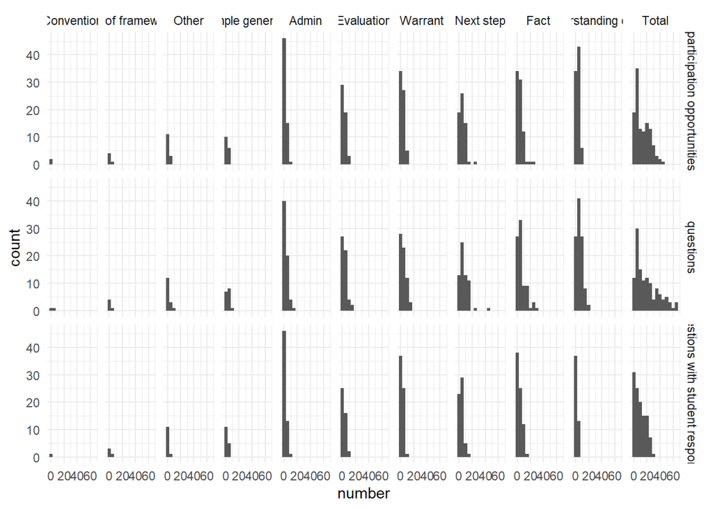

```r
plot_summary <- function(counts_by_lecture_inc_totals) {

counts_by_lecture_inc_totals %>%
  mutate(
    code_name = fct_reorder(code_name, num_q, .fun = sum)
  ) %>%
  pivot_longer(
    cols = contains("num_"),
    names_to = "type",
    values_to = "number"
  ) %>%
  mutate(
    type = case_when(
      type == "num_q" ~ "questions",
      type == "num_sr" ~ "questions with student response",
      type == "num_po" ~ "participation opportunities"
    )
  ) %>%
  # This is used to omit cases where the count is 0, to avoid overly spiky histograms
  filter(number > 0) %>%
  ggplot(aes(x = number)) +
  facet_grid(type ~ code_name) +
  geom_histogram(binwidth = 5) +
  theme_minimal()

}

counts_by_lecture_inc_totals %>%
  #filter(code_name %in% c("Proof framework")) %>%
  plot_summary()
```

## Summary - mathematical questions only

Here we remove the `Admin` and `Understanding check` categories.

```r
counts_by_lecture_inc_totals_noAU <- counts_by_lecture %>%
  filter(!code_name %in% c("Admin", "Understanding check")) %>%
  add_group_totals()

counts_by_lecture_summary_table_noAU <- produce_summary_table(counts_by_lecture_inc_totals_noAU)

counts_by_lecture_summary_table_noAU %>%
  show_summary_table()
```

| Question category | Mean number of questions per lecture (s.d.) | Mean number of student responses per lecture (as % of category) | Mean number of participation opportunities per lecture (as % of category) |
| --- | --- | --- | --- |
| Fact | 3.79 (5.86) | 2.01 (53%) | 2.63 (69%) |
| Next step | 3.58 (6.17) | 1.68 (47%) | 2.4 (67%) |
| Warrant | 2.24 (3.6) | 1.29 (58%) | 1.6 (72%) |
| Evaluation | 1.54 (2.8) | 0.81 (52%) | 1.07 (70%) |
| Example generation | 0.39 (1.28) | 0.25 (64%) | 0.28 (72%) |
| Other | 0.28 (1.02) | 0.12 (42%) | 0.17 (61%) |
| Proof framework | 0.06 (0.34) | 0.05 (88%) | 0.06 (100%) |
| Convention | 0.03 (0.27) | 0.01 (25%) | 0.01 (50%) |
| Total | 11.91 (13.55) | 6.21 (52%) | 8.24 (69%) |

Version of this table with grouped columns, and corresponding LaTeX code for the manuscript:

```r
counts_by_lecture_summary_table_noAU %>%
    select(
      code_name,
      num_q_mean,
      num_q_sd,
      num_sr_mean,
      num_sr_mean_pc,
      num_po_mean,
      num_po_mean_pc
    ) %>%
    kable(booktabs = T,
          col.name = c("Question category",
                       "M", "SD",
                       "M", "% of category",
                       "M", "% of category")) %>%
    kable_styling(full_width = T) %>%
    add_header_above(c(" " = 1, "Questions per lecture" = 2, "Student responses per lecture" = 2, "Participation opportunities per lecture" = 2))
```

| Question category | Questions per lecture M | Questions per lecture SD | Student responses per lecture M | Student responses per lecture % of category | Participation opportunities per lecture M | Participation opportunities per lecture % of category |
| --- | --- | --- | --- | --- | --- | --- |
| Fact | 3.79 | 5.86 | 2.01 | 53 | 2.63 | 69 |
| Next step | 3.58 | 6.17 | 1.68 | 47 | 2.40 | 67 |
| Warrant | 2.24 | 3.60 | 1.29 | 58 | 1.60 | 72 |
| Evaluation | 1.54 | 2.80 | 0.81 | 52 | 1.07 | 70 |
| Example generation | 0.39 | 1.28 | 0.25 | 64 | 0.28 | 72 |
| Other | 0.28 | 1.02 | 0.12 | 42 | 0.17 | 61 |
| Proof framework | 0.06 | 0.34 | 0.05 | 88 | 0.06 | 100 |
| Convention | 0.03 | 0.27 | 0.01 | 25 | 0.01 | 50 |
| Total | 11.91 | 13.55 | 6.21 | 52 | 8.24 | 69 |

```
##
## \begin{tabu} to \linewidth {>{\raggedright}X>{\raggedleft}X>{\raggedleft}X>{\raggedleft}X>{\raggedleft}X>{\raggedleft}X>{\raggedleft}X}
## \toprule
## \multicolumn{1}{c}{ } & \multicolumn{2}{c}{Questions per lecture} & \multicolumn{2}{c}{Student responses per lecture} & \multicolumn{2}{c}{Participation opportunities per lecture} \\
## \cmidrule(l{3pt}r{3pt}){2-3} \cmidrule(l{3pt}r{3pt}){4-5} \cmidrule(l{3pt}r{3pt}){6-7}
## Question category & M & SD & M & \% of category & M & \% of category\\
## \midrule
## Fact & 3.79 & 5.86 & 2.01 & 53 & 2.63 & 69\\
## Next step & 3.58 & 6.17 & 1.68 & 47 & 2.40 & 67\\
## Warrant & 2.24 & 3.60 & 1.29 & 58 & 1.60 & 72\\
## Evaluation & 1.54 & 2.80 & 0.81 & 52 & 1.07 & 70\\
## Example generation & 0.39 & 1.28 & 0.25 & 64 & 0.28 & 72\\
## \addlinespace
## Other & 0.28 & 1.02 & 0.12 & 42 & 0.17 & 61\\
## Proof framework & 0.06 & 0.34 & 0.05 & 88 & 0.06 & 100\\
## Convention & 0.03 & 0.27 & 0.01 & 25 & 0.01 & 50\\
## Total & 11.91 & 13.55 & 6.21 & 52 & 8.24 & 69\\
## \bottomrule
## \end{tabu}
```

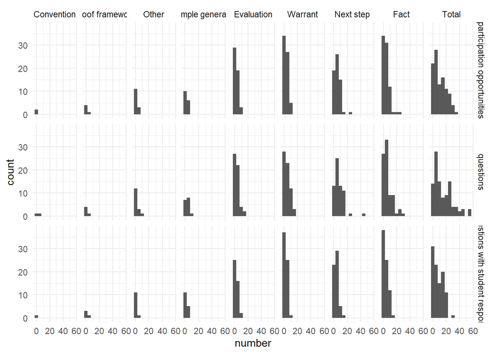

```r
plot_summary(counts_by_lecture_inc_totals_noAU)
```